# Analiza losów absolwentów PSW (2021)

Wydział Nauk o Zdrowiu

zespół d/s ZJK

01/12/2021

## Opis procedury zbierania i analizy danych

Informacje nt losów absolwentów PSW są pozyskiwane za pomocą anonimowej ankiety udostępnianej absolwentom w postaci **formularza internetowego**.

Ankieta zawiera 21 pytań dotyczących absolwenta (płeć/wiek/kierunek studiów które ukończył); pracy którą wykonuje w chwili obecnej (pytania 7–10); postrzeganej przydatności w wykonywanym przez nich zawodzie różnych nabytych w czasie studiów umiejętności (pytania 11–16) całościowej oceny szkoły, decyzji odnośnie wybranego kierunku oraz planów dalszej edukacji (pytania 17–21). Uwaga: formularz ankiety został zmieniony/zmodyfikowany w roku 2021 a co za tym idzie badanie absolwentów w roku 2021 jest pierwszym badaniem wykorzystującym nowy kwestionariusz.

Osoby niepracujące nie są pytanie (z oczywistych względów) o wykonywaną pracę i przydatność w tej pracy nabytych w czasie studiów umiejętności. W tym aspekcie analizowane są tylko odpowiedzi od osób pracujących. **Uwaga**: ponieważ liczba ankiet wypełnionych przez osoby które zadeklarowały że obecnie **nie pracują** była bardzo niska (kilka osób); nie analizowano *ilościowo* tej grupy absolwentów.

**Kompletny formularz ankiety zamieszono na końcu niniejszego opracowania.**

Analiza statystyczna ankiet jest wykonywana za pomocą **autorskiego programu WSZJK-PSW** (w języku R) stworzonego przez członków zespołu d/s **Zapewnienia Jakości Kształcenia**. **Dzięki zautomatyzowaniu przetwarzania danych (w miejsce używania powszechnie do tego celu oprogramowania biurowego) udało się znacząco obniżyć koszty, zmniejszyć liczbę błędów oraz zapewnić 100% powtarzalność analiz**.

Ten dokument został wygenerowany właśnie w systemie **WSZJK-PSW**.

Raporty niniejszy opisuje badanie wykonane bezpośrednio po ukończeniu studiów.

W ankiecie wzięło udział (pracujących) 30 absolwentów. Poniższe zestawienie przedstawia rozkład absolwentów ze względu na kierunki, na których studiowali:

| Kierunek | liczba studentów |
| --- | --- |
| pielęgniarstwo | 13 |
| pielęgniarstwo pomostowe | 10 |
| ratownictwo medyczne | 7 |

## Podstawowe informacje o ankietowanych absolwentach

Struktura według płci, sektora w których pracują, typu zatrudnienia

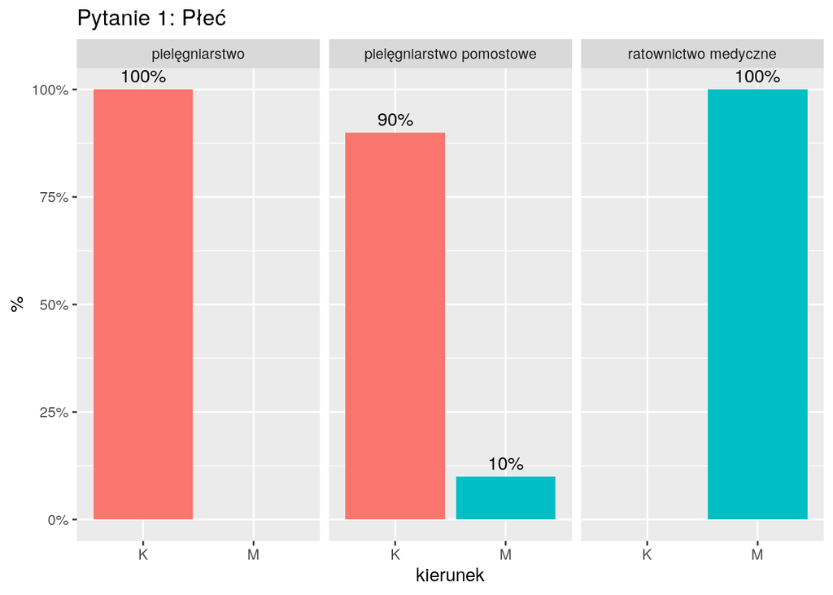

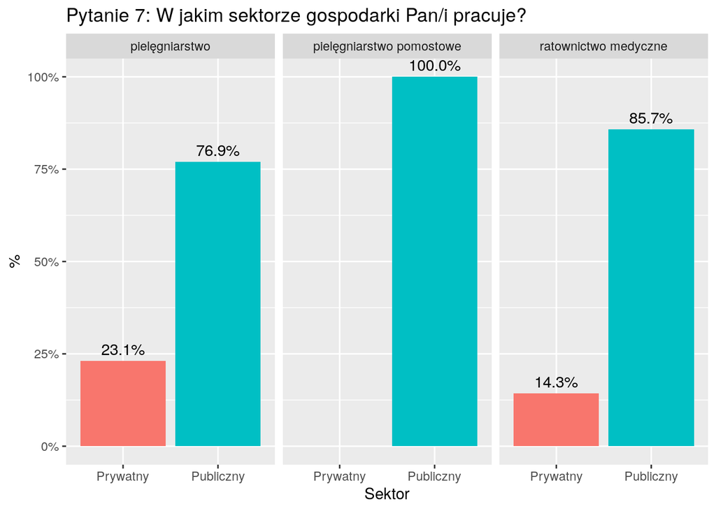

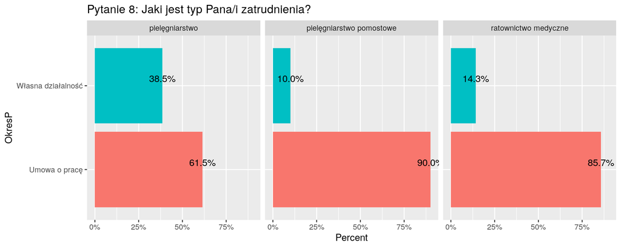

## Satysfakcja zawodowa

Pytania 9–10 oceniały satysfakcję z wykonywanej obecnie pracy w aspekcie ogólnym oraz finansowym

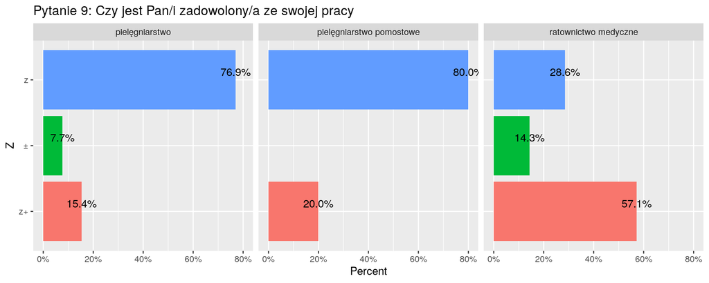

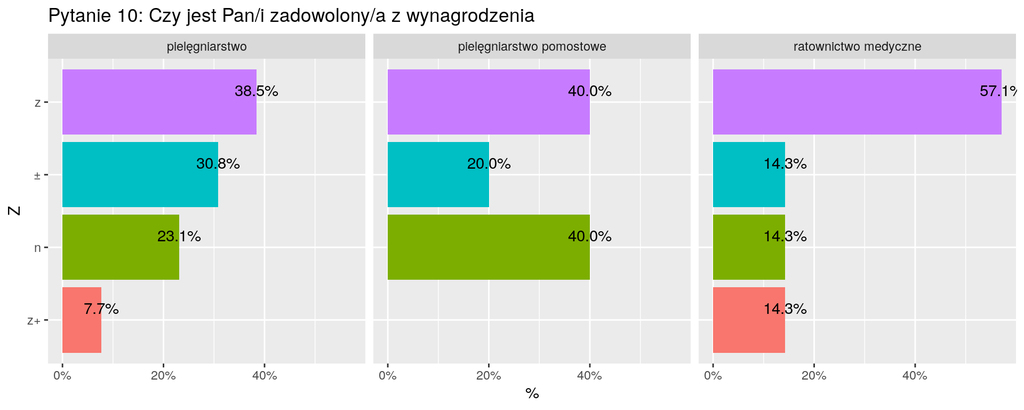

### Ocena umiejętności nabytych w czasie studiowania

Pytania 11–16 dotyczyły postrzeganej przez ankietowanych przydatności w wykonywanym przez nich zawodzie różnych nabytych w czasie studiów umiejętności

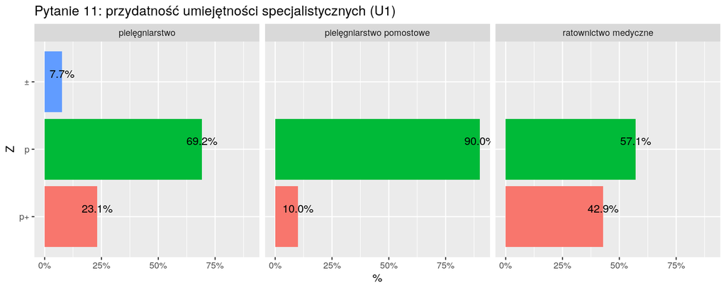

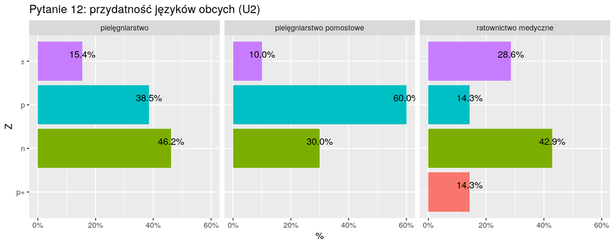

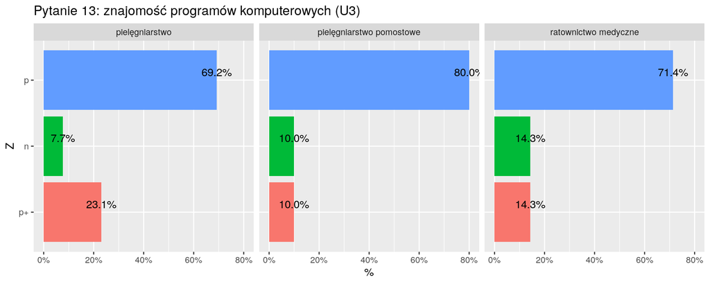

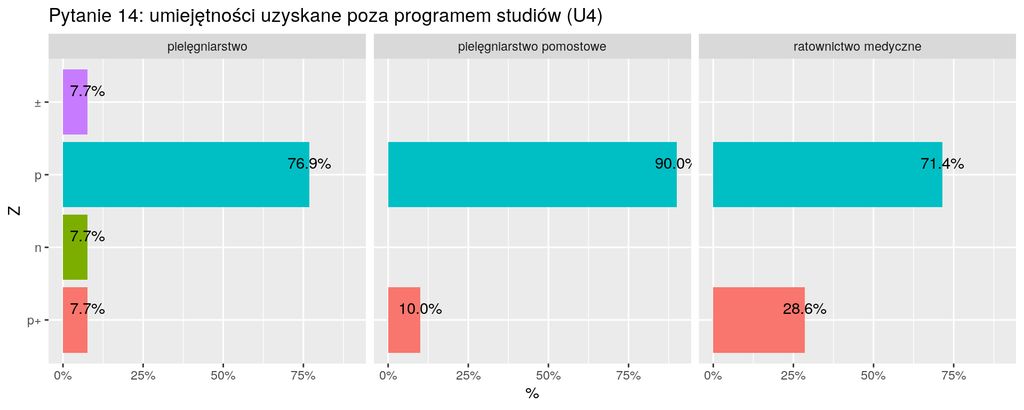

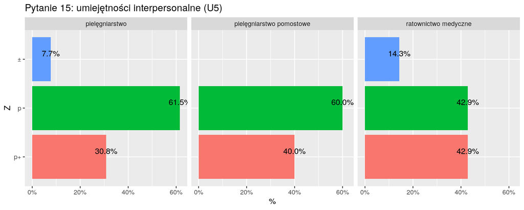

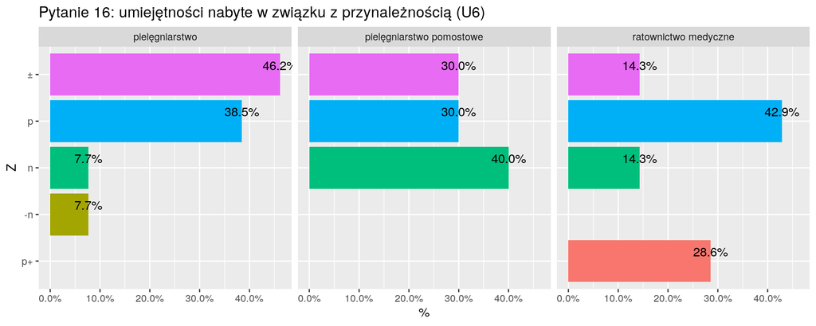

Łączny ranking umiejętności ocenionych w pytaniach 11–16. Poszczególne umiejętności zestawiono wg odsetka odpowiedzi przydają/bardzo przydają.

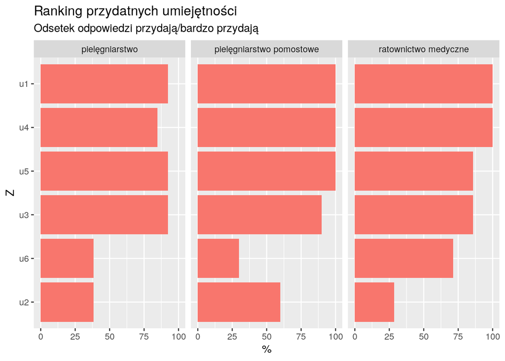

Zwraca uwagę niska pozycja U6/U2, tj. **Znajomość języków obcych** oraz oraz **Umiejętności nabyte w związku z przynależnością do organizacji studenckich, koła naukowego, organizacji pozarządowej, politycznej, sportowej, charytatywnej**

## Ocena ogólna, szkoły podjętej decyzji co do studiowania oraz plany na przyszłość.

Pytania 17–21 dotyczą oceny przydatności programu studiów, decyzji co słuszności wyboru kierunku oraz planów dotyczących ewentualnej dalszej edukacji.

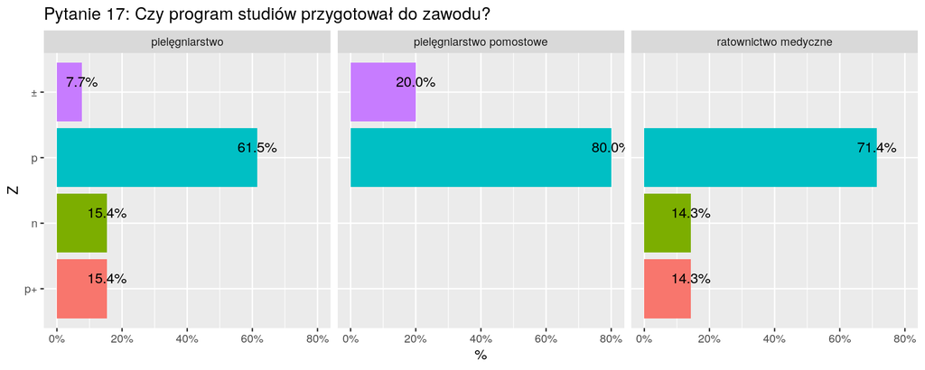

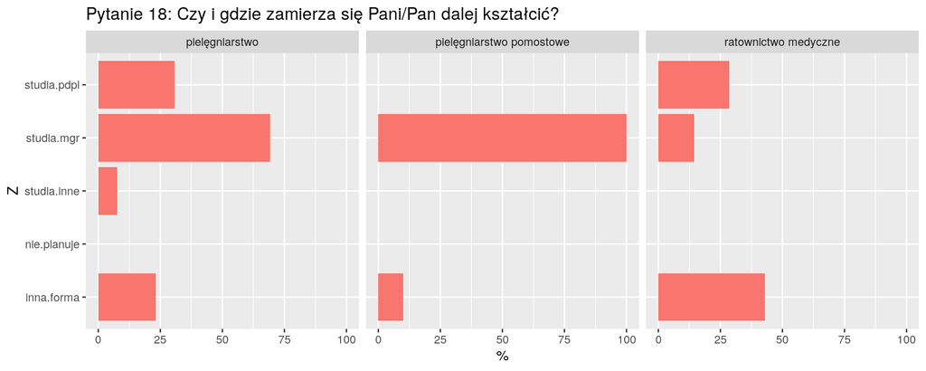

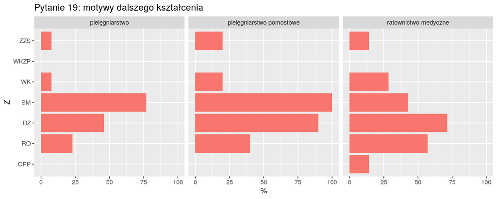

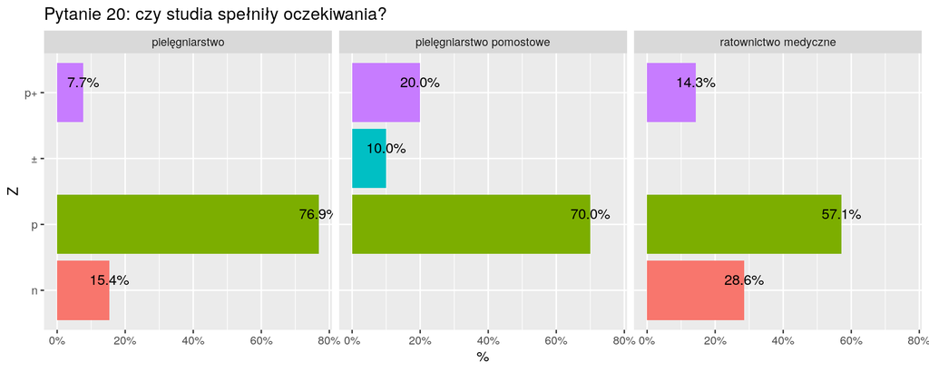

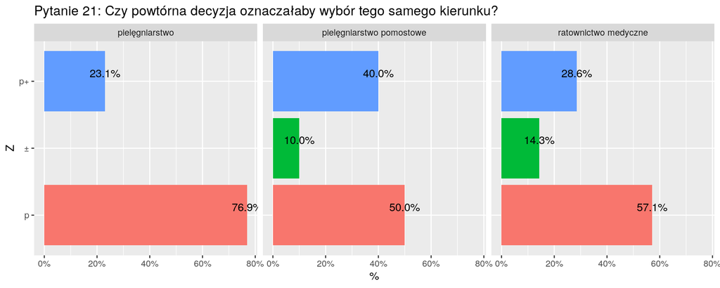

## Ankieta absolwenta

Formularz ankiety dla absolwenta pracującego

Ankieta asolwenta PSW. Prosimy opodanie informacji nt swojej kariery zawodowej oraz o ocenę szkoły.

1. Płeć [] kobieta [] mężczyna
2. Rok ukończenia studiów
3. Tryb [] stacjonarne [] niestacjonarne
4. Wiek (lata) [] 18–24 [] 25–30 [] 31–36 [] 37–42 [] 43–48 [] 49–54 [] 55 i więcej
5. Kierunek: [] Ekonomia [] Pielęgniarstwo [] Pielęgniarstwo pomostowe [] Ratownictwo medyczne []Kosmetologia
6. W jakim sektorze Pan/i pracuje: [] publiczny [] prywatny
7. W jakiej dziedzinie sektora gospodarki Pan/i obecnie pracuje: [] przemysł [] budownictwo [] usługi []edukacja []zdrowie []administracja inne []
8. Typ zatrudnienia: []Umowa o pracę []Umowa zlecenie/dzieło []Staż/praktyka []Bez umowy []Własna działalność
9. Czy jest Pan/i zadowolony z wykonywanej pracy []{
10. Czy jest Pan/i zadowolony z poziomu wynagrodzenia{
11. Czy umiejętności specjalistyczne nabyte na studiach przydają się Panu/Pani w wykonywanej aktualnie pracy: []całkowicie się nie przydają [] nie przydają [] trudno powiedzieć []przydają [] bardzo przydają
12. Znajomość języków obcych przydaje się Panu/Pani w wykonywanej aktualnie pracy: []całkowicie się nie przydają [] nie przydają [] trudno powiedzieć []przydają [] bardzo przydają
13. Znajomość obsługi programów komputerowych przydają się Panu/Pani w wykonywanej aktualnie pracy:

[]całkowicie się nie przydają [] nie przydają [] trudno powiedzieć []przydają [] bardzo przydają

14. Umiejętności zawodowe uzyskane poza programem studiów (kursy/szkolenia) przydają się Panu/Pani w wykonywanej aktualnie pracy:

[]całkowicie się nie przydają [] nie przydają [] trudno powiedzieć []przydają [] bardzo przydają

15. Umiejętności interpersonalne przydają się Panu/Pani w wykonywanej aktualnie pracy:

[]całkowicie się nie przydają [] nie przydają [] trudno powiedzieć []przydają [] bardzo przydają

16. Umiejętności nabyte w związku z przynależnością do organizacji studenckich, koła naukowego, organizacji pozarządowej, politycznej, sportowej, charytatywnej, itp. przydają się Panu/Pani w wykonywanej aktualnie pracy:

[]całkowicie się nie przydają [] nie przydają [] trudno powiedzieć []przydają [] bardzo przydają

17. Czy program studiów w PSW pozwolił Panu/Pani osiągnąć niezbędną wiedzę, umiejętności i kompetencje społeczne do wykonywania zawodu:

[]zdecydowanie nie [] nie [] trudno powiedzieć []tak [] zdecydowanie tak

18. Czy zamierza się Pan/i dalej kształcić lub czy już Pan/i się kształci? (można zaznaczyć więcej niż jedną odpowiedź):

    [] tak, na studiach magisterskich [] tak, na studiach podyplomowych/szkolenich [] tak, na innych studiach wyższych (doktoranckie, MBA) [] tak, w innej formie (jakiej?) [] nie planuję
19. Jakie są Pana/Pani motywy podjęcia dalszego kształcenia (można zaznaczyć więcej niż jedną odpowiedź)

    [] zwiększenie szansy znalezienia pracy [] wymagania kwalifikacyjne związane z wykonywaną pracą (zdobycie uprawnień) [] wymagania kwalifikacyjne niezbędne do zmiany pracy [] chęć rozwoju zawodowego [] chęć poprawy statusu materialnego [] zainteresowanie tematyką kształcenia (rozwój osobisty) [] oddelegowanie przez pracodawcę [] inne (jakie?)
20. Czy studia spełniły Pana/Pani oczekiwania?

[]zdecydowanie nie [] nie [] trudno powiedzieć []tak [] zdecydowanie tak

21. Czy gdyby Pan/i jeszcze raz podejmował/a decyzję o wyborze studiów to wybrałby/ałaby Pan/i ten sam kierunek?

[]zdecydowanie nie [] nie [] trudno powiedzieć []tak [] zdecydowanie tak